# README

Jean-Philippe Rasigade

26 mars 2020

# Time-scaled haplotypic density (THD) for R.

THD is an R package for estimating and comparing the evolutionary success of individuals in a population based on genetic distances.

The primary application of THD is the quantitative analysis and identification of factors that influence the epidemic success of pathogens. The approach assigns a index of epidemic success to each individual in a population. This index is then typically used as the response variable in multivariate models including potential predictors of success. See the publication list below for practical applications.

## Installation

Make sure the `devtools` package is installed then run

```r
devtools::install_github("rasigadelab/thd")
```

## Input and parameters

THD analysis requires a matrix of genetic distances and three user-defined parameters:

- `t` is the *timescale* parameter that controls the length of time considered in analysis. Shorter `t` estimates success in recent times while longer `t` considers long-term evolution. The choice depends on the evolutionary dynamics of the population. `t`can be as small as 1 month for a fast-spreading viral epidemic or several hundred years for historical diseases such as tuberculosis.
- `m` is the number of *markers* used for computing the genetic distances. These markers can be anything from minisatellites to nucleotides as long as they convey a phylogenetic signal. For typical whole genome-based applications, `m` is the effective genome size, i.e. the pathogen’s genome size minus the size of regions excluded from analysis (typically repeated or low-quality regions).
- `mu` is the *mutation* (or substitution) rate for each marker per unit of time. This unit of time must be the same as the one used in `t`.

## Toy example

We compute and plot THD values for a synthetic, minimalistic example of 6 individuals.

Load the package and simulate a toy matrix of genetic distances with 3 very similar individuals (A to C) and 3 more distant individuals (D to E).

```r
library(thd)
H <- matrix(c(
  00, 00, 00, 00, 00, 00,
  01, 00, 00, 00, 00, 00,
  03, 01, 00, 00, 00, 00,
  21, 18, 28, 00, 00, 00,
  23, 25, 31, 07, 00, 00,
  19, 27, 23, 09, 11, 00
), ncol = 6, byrow = TRUE)
```

Make the matrix symmetric and assign names to individuals (THD keeps track of column names in its output).

```r
H <- H + t(H)
colnames(H) <- LETTERS[1:ncol(H)]
```

Choose parameters. Suppose we used 64 markers, each with a substitution rate of 0.001 per marker per year, and we are interested in a timescale of 10 years.

```r
m <- 64
mu <-  0.001
t <- 10
```

Use the `thd` function to compute indices. The `scale = time` option scales the output relative to the timescale (use `?thd` for details on scaling options).

```r
x <- thd(H, t, m, mu, scale = "time")
```

Visualize the results along with a dendrogram of the isolates.

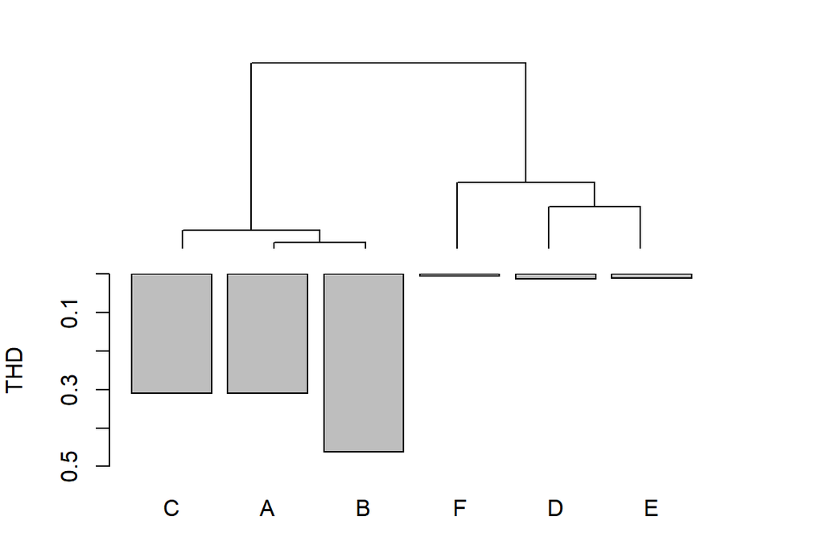

```r
hc <- hclust(as.dist(H))
par(mfrow = c(2, 1))
par(mar = c(0, 6, 2, 6))
plot(hc, hang = -1, xlab = "", yaxt = "n", ylab = "", main = "", labels = FALSE)
par(mar = c(3, 4, 0, 4))
barplot(x[hc$order], ylim = c(0.5, 0), ylab = "THD")
```

## References

Rasigade JP, Barbier M, Dumitrescu O, Pichat C, Carret G, Ronnaux-Baron AS, Blasquez G, Godin-Benhaim C, Boisset S, Carricajo A, Jacomo V, Fredenucci I, Pérouse de Montclos M, Flandrois JP, Ader F, Supply P, Lina G, Wirth T. Strain-specific estimation of epidemic success provides insights into the transmission dynamics of tuberculosis. Sci Rep. 2017 Mar 28;7:45326. doi: 10.1038/srep45326. PMID: 28349973

Barbier M, Dumitrescu O, Pichat C, Carret G, Ronnaux-Baron AS, Blasquez G, Godin-Benhaim C, Boisset S, Carricajo A, Jacomo V, Fredenucci I, Pérouse de Montclos M, Genestet C, Flandrois JP, Ader F, Supply P, Lina G, Wirth T, Rasigade JP. Changing patterns of human migrations shaped the global population structure of Mycobacterium tuberculosis in France. Sci Rep. 2018 Apr 11;8(1):5855. doi: 10.1038/s41598-018-24034-6. PMID: 29643428

Thierry Wirth, Marine Bergot, Jean-Philippe Rasigade, Bruno Pichon, Maxime Barbier, Patricia Martins-Simoes, Laurent Jacob, Rachel Pike, Pierre Tissieres, Jean-Charles Picaud, Angela Kearns, Philip Supply, Marine Butin, Frédéric Laurent, on behalf of the International Consortium for Staphylococcus capitis neonatal sepsis and the ESGS group of ESCMID. Niche specialization and spread of a multidrug-resistant Staphylococcus capitis clone involved in neonatal sepsis. Nat. Microbiol. 2020 (in press)